# Friday homework: random forests, AdaBoost and XGBoost

Hiro, Hendrik, Stefan

14 October 2026

# 0. Data and train/test split

Same data, window and chronological 80/20 split as in the previous homeworks: the 2000-2018 window, the first 80% of months for training and the last 20% for testing, with no shuffling. `R1M_Usd` is the regression label and `R1M_Usd_C` (above the median return of its month) is the classification label. A seed is set before every model that uses random sampling, always the same one (42).

```r
library(tidyverse)
library(lubridate)
library(knitr)
library(randomForest)
library(fastAdaboost)
library(xgboost)

load("data_ml.RData")                                   # Load the raw dataset
data_ml <- data_ml %>%
  filter(date > "1999-12-31", date < "2019-01-01") %>%   # Keep only the 2000-2018 window
  arrange(stock_id, date)                                # Sort by stock, then time

features <- colnames(data_ml[3:95])                     # Full feature set: 93 predictors
features_short <- c("Div_Yld", "Eps", "Mkt_Cap_12M_Usd", "Mom_11M_Usd",
                    "Ocf", "Pb", "Vol1Y_Usd")           # Short feature set: 7 predictors

dates <- sort(unique(data_ml$date))                     # All distinct months, in order
split_date <- dates[floor(0.8 * length(dates))]         # Date marking the 80% point in time

add_label <- function(df){
  df %>%
    group_by(date) %>%                                   # Compare stocks within each month
    mutate(R1M_Usd_C = as.factor(R1M_Usd > median(R1M_Usd))) %>%   # Above-median = TRUE
    ungroup()
}
data_ml <- add_label(data_ml)

training_sample <- data_ml %>% filter(date <= split_date)   # First 80% of months
testing_sample  <- data_ml %>% filter(date >  split_date)   # Last 20% of months, no overlap
y_test <- testing_sample$R1M_Usd

formula_full  <- as.formula(paste("R1M_Usd ~",   paste(features,       collapse = " + ")))
formula_short <- as.formula(paste("R1M_Usd ~",   paste(features_short, collapse = " + ")))
formula_C     <- as.formula(paste("R1M_Usd_C ~", paste(features,       collapse = " + ")))

mse <- function(p) mean((p - y_test)^2)                 # Test MSE
hit <- function(p) mean(p * y_test > 0)                 # Hit ratio: share of correct signs
pct <- function(x) paste0(formatC(100 * x, format = "f", digits = 1), "%")
f6  <- function(x) formatC(x, format = "f", digits = 6)

pred_naive <- rep(mean(training_sample$R1M_Usd), length(y_test))   # Always the training mean
```

Chronological 80/20 split

| Sample | From | To | Observations |
| --- | --- | --- | --- |
| Training | 2000-01-31 | 2015-02-28 | 214821 |
| Test | 2015-03-31 | 2018-12-31 | 53515 |

# 1. Random-forest regression benchmark

```r
set.seed(42)
fit_RF <- randomForest(formula_full, data = training_sample,   # Chapter 6-style settings
                       sampsize = 10000, replace = FALSE,      # Each tree: 10,000 stocks, no repeats
                       nodesize = 250,                         # At least ~250 stocks per leaf
                       ntree = 40, mtry = 30)                  # 40 trees, 30 random features per split

pred_RF <- predict(fit_RF, testing_sample)
mse_RF <- mse(pred_RF)
hit_RF <- hit(pred_RF)
```

Random-forest regression on the test sample

| Model | Test MSE | Hit ratio | Share predicted up |
| --- | --- | --- | --- |
| Random forest (93 features) | 0.045657 | 0.528637 | 0.929683 |
| Naive (training mean) | 0.045774 | 0.532056 | 1.000000 |

**Answer.** The random forest (93 features) has a test MSE of 0.045657 and a hit ratio of 52.9%. Its MSE is slightly better than the naive forecast (0.045774), but its hit ratio is slightly below the naive 53.2%. The forest predicts “up” for 93.0% of the stocks, so the hit ratio mostly reflects the share of positive returns. The five tuning parameters work as follows.

- **`ntree`** is the number of trees that are averaged. More trees make the average more stable.
- **`mtry`** is the number of features a tree may consider at each split (30 of 93). A small `mtry` forces the trees to use different features.
- **`sampsize`** is the number of stocks each tree is grown on (10,000). A smaller sample is faster and makes the trees more different from each other.
- **`replace`** says whether this sample is drawn with replacement (bootstrap) or without. Here it is `FALSE`, so each tree sees 10,000 different stocks.
- **`nodesize`** is the minimum size of the leaves (250). Larger leaves give smoother trees that are less likely to fit noise.

# 2. How many trees?

```r
set.seed(42)
train_sub <- training_sample %>% slice_sample(n = 20000)   # One fixed training subset for all models

ntrees <- c(10, 20, 40, 80, 160)
rf_trees <- lapply(ntrees, function(nt){
  set.seed(42)                                              # Same seed for every specification
  fit <- randomForest(formula_short, data = train_sub,      # Short feature set (7 predictors)
                      sampsize = 10000, replace = FALSE, nodesize = 250,
                      ntree = nt, mtry = 4)                 # 4 of the 7 features tried at each split
  p <- predict(fit, testing_sample)
  tibble(Trees = nt, `Test MSE` = mse(p), `Hit ratio` = hit(p), `Share predicted up` = mean(p > 0))
}) %>% bind_rows()
```

Random forest with 7 features: number of trees

| Trees | Test MSE | Hit ratio | Share predicted up |
| --- | --- | --- | --- |
| 10 | 0.046001 | 0.526394 | 0.856414 |
| 20 | 0.045839 | 0.527254 | 0.881753 |
| 40 | 0.045787 | 0.528917 | 0.898066 |
| 80 | 0.045768 | 0.528469 | 0.905615 |
| 160 | 0.045741 | 0.528151 | 0.905933 |

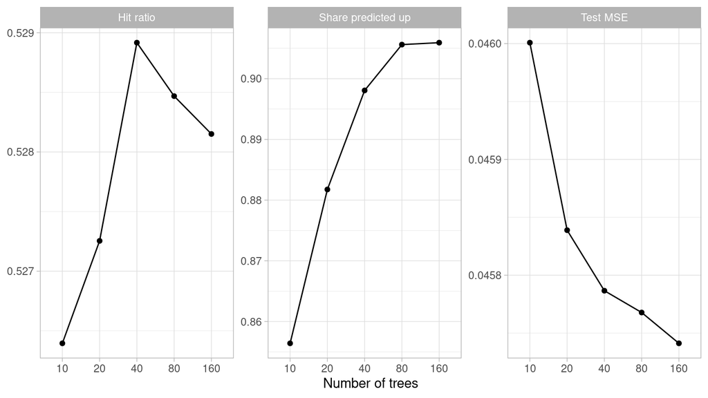

**Answer.** The test MSE falls from 0.046001 with 10 trees to 0.045787 with 40 trees and 0.045741 with 160 trees. Most of the gain comes with the first 20-40 trees. Going from 80 to 160 trees improves the MSE by only 0.000027. The hit ratio hardly moves (between 52.6% and 52.9%). So adding trees is worthwhile up to roughly 40-80 trees, because it removes randomness. After that it is cheap but brings almost nothing. More trees do not cause overfitting, but they cannot add information that the features do not contain.

# 3. Feature randomness in random forests

```r
fit_mtry <- function(m){
  set.seed(42)
  fit <- randomForest(formula_full, data = training_sample,    # Exercise 1 specification
                      sampsize = 10000, replace = FALSE, nodesize = 250,
                      ntree = 40, mtry = m)
  all_trees <- predict(fit, testing_sample, predict.all = TRUE)$individual   # One column per tree
  cors <- cor(all_trees)                                       # Correlation between trees' forecasts
  p <- predict(fit, testing_sample)
  tibble(mtry = m, `Test MSE` = mse(p), `Hit ratio` = hit(p), `Share predicted up` = mean(p > 0),
         `Average correlation between trees` = mean(cors[upper.tri(cors)]))
}
rf_mtry <- bind_rows(fit_mtry(5), fit_mtry(30))
```

Random forest: mtry = 5 versus mtry = 30

| mtry | Test MSE | Hit ratio | Share predicted up | Average correlation between trees |
| --- | --- | --- | --- | --- |
| 5 | 0.045639 | 0.529253 | 0.950182 | 0.050120 |
| 30 | 0.045657 | 0.528637 | 0.929683 | 0.047745 |

**Answer.** Both models are practically equal: 0.045639 with `mtry` = 5 and 0.045657 with `mtry` = 30, and hit ratios of 52.9% and 52.9%. A larger `mtry` is not simply “better” or “worse”. It is a trade-off. With a large `mtry`, every tree can use the strongest features at the top, so the trees look alike and averaging them removes less noise. With a small `mtry`, the trees are forced to use different features, so they become more different from each other and the average is more stable, but each single tree is weaker. In our run the average correlation between the trees’ forecasts is low in both cases (0.050120 and 0.047745) and, against what we expected, not lower for `mtry` = 5. The difference is tiny, so with such weak signals the trees differ mainly because of the random subsamples and not because of `mtry`.

# 4. Random-forest classification

```r
set.seed(42)
fit_RF_C <- randomForest(formula_C, data = training_sample,
                         sampsize = 20000, replace = FALSE,             # 20,000 stocks per tree, as in the chapter
                         nodesize = 250, ntree = 40, mtry = 30)

pred_RF_C <- predict(fit_RF_C, testing_sample)
conf_RF   <- table(Predicted = pred_RF_C, Actual = testing_sample$R1M_Usd_C)
acc_RF_C  <- mean(pred_RF_C == testing_sample$R1M_Usd_C)

share_true <- mean(testing_sample$R1M_Usd_C == "TRUE")
share_pos  <- mean(y_test > 0)
```

Confusion matrix, random-forest classification (test sample)

|  | FALSE | TRUE |
| --- | --- | --- |
| FALSE | 15012 | 14569 |
| TRUE | 11936 | 11998 |

Accuracy and hit ratio against their own baselines

| Model | Question | Score | Baseline | Share predicted up |
| --- | --- | --- | --- | --- |
| RF classification | Above the monthly median? | 0.505 | 0.504 | 0.447 |
| RF regression (Exercise 1) | Positive return? | 0.529 | 0.532 | 0.930 |

**Answer.** The classification forest has a test accuracy of 50.5%, practically the same as the 50.4% that one gets by always predicting the more common class (a difference well within the sampling noise of about 0.2 points). The confusion matrix shows that it is almost a coin flip. The comparison with the regression forest (52.9% hit ratio, against a baseline of 53.2%) is informative because neither model clearly beats its own baseline. It is not apples-to-apples for three reasons. The two models answer different questions (“beats the monthly median?” versus “return above zero?”). Their baselines differ (50.4% versus 53.2%). And the regression forest predicts “up” for 93.0% of the stocks, so its hit ratio mostly reflects the share of positive returns, while the classification forest predicts “up” for only 44.7%.

# 5. AdaBoost classifier

```r
set.seed(42)
train_ada <- training_sample %>% slice_sample(n = 10000)       # AdaBoost on a 10,000-stock subsample

fit_ada <- adaboost(formula_C, data = as.data.frame(train_ada), nIter = 3)
pred_ada <- predict(fit_ada, newdata = as.data.frame(testing_sample))$class
acc_ada <- mean(pred_ada == testing_sample$R1M_Usd_C)
```

AdaBoost classification on the test sample

| Model | Test accuracy | Share predicted up |
| --- | --- | --- |
| AdaBoost, nIter = 3 | 0.5 | 0.504 |

**Answer.** AdaBoost with 3 iterations has a test accuracy of 50.0%, which is a coin flip (baseline about 50%). AdaBoost builds a sequence of trees. At the start, all observations have the same weight. After each tree, the observations that it classified wrongly get a higher weight and the correct ones get a lower weight, so the next tree concentrates on the hard cases. At the end, the trees vote, and trees with fewer mistakes get more say in the vote.

# 6. AdaBoost iterations

```r
ada_iter <- lapply(c(3, 10, 20), function(k){
  set.seed(42)
  fit <- adaboost(formula_C, data = as.data.frame(train_ada), nIter = k)   # Same subsample, same settings
  tibble(nIter = k,
         `Training accuracy` = mean(predict(fit, newdata = as.data.frame(train_ada))$class == train_ada$R1M_Usd_C),
         `Test accuracy` = mean(predict(fit, newdata = as.data.frame(testing_sample))$class == testing_sample$R1M_Usd_C))
}) %>% bind_rows()
```

AdaBoost: number of iterations

| nIter | Training accuracy | Test accuracy |
| --- | --- | --- |
| 3 | 0.9395 | 0.5000 |
| 10 | 0.9998 | 0.5017 |
| 20 | 1.0000 | 0.5021 |

**Answer.** Training accuracy rises quickly: 94.0% with 3 iterations, 100.0% with 10 and 100.0% with 20. Test accuracy stays at 50.0%, 50.2% and 50.2%. The differences of about 0.2 percentage points are within the sampling noise of the test sample (standard error about 0.2 points). So more boosting does not always help. It fits the training sample better and better (up to 100%), which means it memorises noise, but this does not carry over to the future. A better in-sample fit is not evidence of predictive power.

# 7. XGBoost regression benchmark

```r
train_xgb <- training_sample %>%
  group_by(date) %>%
  mutate(quintile = ntile(R1M_Usd, 5)) %>%                   # Quintile of the return within each month
  ungroup() %>%
  filter(quintile %in% c(1, 5))                              # Keep bottom and top quintile = extreme 40%

dtrain <- xgb.DMatrix(data  = as.matrix(train_xgb[, features_short]),
                      label = train_xgb$R1M_Usd)
x_test_xgb <- as.matrix(testing_sample[, features_short])       # Evaluate on the FULL test sample

xgb_params <- list(objective = "reg:squarederror",
                   eta = 0.3,                 # Learning rate: weight of each new tree
                   gamma = 0.1,               # Penalty on the number of leaves
                   lambda = 1,                # Penalty on leaf values
                   max_depth = 4,             # Depth of each tree
                   subsample = 0.6,           # Share of rows used per tree
                   colsample_bytree = 0.7,    # Share of features used per tree
                   nthread = 2)

set.seed(42)
fit_xgb <- xgb.train(params = xgb_params, data = dtrain, nrounds = 30)
pred_xgb <- predict(fit_xgb, x_test_xgb)
mse_xgb <- mse(pred_xgb)
hit_xgb <- hit(pred_xgb)
```

XGBoost regression on the full test sample

| Model | Test MSE | Hit ratio | Share predicted up |
| --- | --- | --- | --- |
| XGBoost (7 features, extreme 40% of labels) | 0.046297 | 0.517911 | 0.790246 |
| Naive (training mean) | 0.045774 | 0.532056 | 1.000000 |

**Answer.** With the book-style setup (7 features, only the bottom and top quintile of each month’s training returns), XGBoost has a test MSE of 0.046297 and a hit ratio of 51.8%. This is worse than the naive forecast (0.045774, 53.2%). The model is trained only on extreme returns, so it learns to separate big winners from big losers. But it is evaluated on all stocks, most of which have ordinary returns, so its forecasts are more spread out than those of the random forest, and the sign is close to a coin flip. The shallower models in Exercise 8 do better on MSE.

# 8. XGBoost complexity

```r
xgb_depth <- lapply(c(2, 4, 6), function(d){
  set.seed(42)
  fit <- xgb.train(params = modifyList(xgb_params, list(max_depth = d)),   # Only max_depth changes
                   data = dtrain, nrounds = 30)
  p <- predict(fit, x_test_xgb)
  p_train <- predict(fit, as.matrix(training_sample[, features_short]))
  tibble(max_depth = d,
         `Train MSE` = mean((p_train - training_sample$R1M_Usd)^2),
         `Test MSE` = mse(p), `Hit ratio` = hit(p), `Share predicted up` = mean(p > 0))
}) %>% bind_rows()
```

XGBoost: max_depth

| max_depth | Train MSE | Test MSE | Hit ratio | Share predicted up |
| --- | --- | --- | --- | --- |
| 2 | 0.027266 | 0.045104 | 0.514061 | 0.803270 |
| 4 | 0.024953 | 0.046297 | 0.517911 | 0.790246 |
| 6 | 0.020668 | 0.049750 | 0.511819 | 0.745978 |

**Answer.** `max_depth` is the number of levels in each tree. Deeper trees can capture interactions between features, but they also fit noise. The training MSE (measured on the full training sample) falls with depth (0.027266, 0.024953, 0.020668), while the test MSE rises (0.045104, 0.046297, 0.049750). This is the pattern of **overfitting**: more complexity helps in-sample and hurts out-of-sample. We see no sign of underfitting, because the simplest model (depth 2) is the best. Note that the level of the training MSE is not comparable with the test MSE, because the test period is more volatile. Only the trend across depths matters. The hit ratio stays at about 51-52% for all depths, below the naive 53.2%.

# 9. Comparison and interpretation

```r
reg_all <- bind_rows(
  tibble(Model = "RF, 93 features, mtry 30 (Ex. 1)", `Test MSE` = mse_RF, `Hit ratio` = hit_RF,
         `Share predicted up` = mean(pred_RF > 0)),
  tibble(Model = paste0("RF, 7 features, ", rf_trees$Trees, " trees (Ex. 2)"),
         `Test MSE` = rf_trees$`Test MSE`, `Hit ratio` = rf_trees$`Hit ratio`,
         `Share predicted up` = rf_trees$`Share predicted up`),
  tibble(Model = paste0("RF, 93 features, mtry ", rf_mtry$mtry, " (Ex. 3)"),
         `Test MSE` = rf_mtry$`Test MSE`, `Hit ratio` = rf_mtry$`Hit ratio`,
         `Share predicted up` = rf_mtry$`Share predicted up`),
  tibble(Model = paste0("XGBoost, max_depth ", xgb_depth$max_depth, " (Ex. 7-8)"),
         `Test MSE` = xgb_depth$`Test MSE`, `Hit ratio` = xgb_depth$`Hit ratio`,
         `Share predicted up` = xgb_depth$`Share predicted up`)) %>%
  mutate(Family = ifelse(grepl("^RF", Model), "RF", "XGB"))

best_rf  <- reg_all %>% filter(Family == "RF")  %>% slice_min(`Test MSE`, n = 1)
best_xgb <- reg_all %>% filter(Family == "XGB") %>% slice_min(`Test MSE`, n = 1)

final_table <- tibble(
  Model = c(best_rf$Model, best_xgb$Model, "Naive (training mean)"),
  `Test MSE` = c(best_rf$`Test MSE`, best_xgb$`Test MSE`, mse(pred_naive)),
  `Hit ratio` = c(best_rf$`Hit ratio`, best_xgb$`Hit ratio`, hit(pred_naive)),
  `Share predicted up` = c(best_rf$`Share predicted up`, best_xgb$`Share predicted up`, 1))

class_table <- tibble(Classifier = c("Random-forest classification (Ex. 4)", "Best AdaBoost (Ex. 5-6)"),
                      `Test accuracy` = c(acc_RF_C, max(ada_iter$`Test accuracy`)))
```

Regression: best random forest and best XGBoost (chosen by test MSE)

| Model | Test MSE | Hit ratio | Share predicted up |
| --- | --- | --- | --- |
| RF, 93 features, mtry 5 (Ex. 3) | 0.045639 | 0.529253 | 0.950182 |
| XGBoost, max_depth 2 (Ex. 7-8) | 0.045104 | 0.514061 | 0.803270 |
| Naive (training mean) | 0.045774 | 0.532056 | 1.000000 |

Classification accuracy

| Classifier | Test accuracy |
| --- | --- |
| Random-forest classification (Ex. 4) | 0.5047 |
| Best AdaBoost (Ex. 5-6) | 0.5021 |

All regression models tried, ordered by test MSE

| Model | Test MSE | Hit ratio | Share predicted up |
| --- | --- | --- | --- |
| XGBoost, max_depth 2 (Ex. 7-8) | 0.045104 | 0.514061 | 0.803270 |
| RF, 93 features, mtry 5 (Ex. 3) | 0.045639 | 0.529253 | 0.950182 |
| RF, 93 features, mtry 30 (Ex. 1) | 0.045657 | 0.528637 | 0.929683 |
| RF, 93 features, mtry 30 (Ex. 3) | 0.045657 | 0.528637 | 0.929683 |
| RF, 7 features, 160 trees (Ex. 2) | 0.045741 | 0.528151 | 0.905933 |
| RF, 7 features, 80 trees (Ex. 2) | 0.045768 | 0.528469 | 0.905615 |
| RF, 7 features, 40 trees (Ex. 2) | 0.045787 | 0.528917 | 0.898066 |
| RF, 7 features, 20 trees (Ex. 2) | 0.045839 | 0.527254 | 0.881753 |
| RF, 7 features, 10 trees (Ex. 2) | 0.046001 | 0.526394 | 0.856414 |
| XGBoost, max_depth 4 (Ex. 7-8) | 0.046297 | 0.517911 | 0.790246 |
| XGBoost, max_depth 6 (Ex. 7-8) | 0.049750 | 0.511819 | 0.745978 |

**Answer.** **Random forests** grow many trees independently, each on a random subsample of stocks and features, and average them, which mainly reduces variance. **Boosting** grows trees one after another, each trying to correct the mistakes of the previous ones, which reduces bias but can overfit if there are too many or too deep trees. **MSE and hit ratio** measure different things: MSE punishes the size of errors, the hit ratio counts only the sign. The best XGBoost model (depth 2) has the lowest MSE (0.045104) but a hit ratio of only 51.4%. The best random forest has a higher MSE (0.045639) and a hit ratio of 52.9%, which comes mostly from predicting “up” for 95.0% of the stocks. The classification models are at about 50% accuracy. We would investigate the shallow **XGBoost** model further, because it has by far the largest MSE gain over the naive forecast (0.045774, which is 1.5% higher). Before using it as a signal, we would test whether the gain is statistically significant, whether it holds in other periods (the depth was chosen on the test sample), and whether the forecasts rank stocks well enough to make money in a portfolio after costs.